# Data Science - Capstone Milestone Report

WQ

#### This is a milestone report - prelude to the actual final product of a text prediction Shiny app.

# Aims of this report

As highlighted in the “Milestone Report Rubic” There motivation of this report is to:

-Demonstrate that you’ve downloaded the data and have successfully loaded it in.

-Create a basic report of summary statistics about the data sets.

-Report any interesting findings that you amassed so far.

-Get feedback on your plans for creating a prediction algorithm and Shiny app.

## Upload Dataset and Packages needed for the Report

```r
#List of R Packages that will be used in this report.
library(tm)
library(stringi)
library(stringr)
library(RWeka)
library(SnowballC)
library(ggplot2)
library(wordcloud)

#Uploading the datasets
twitter <- readLines("C:/Users/User/Documents/R/final/en_US/en_US.twitter.txt", encoding="UTF-8")
twitter <- iconv(twitter, from="latin1", to="ASCII", sub="")

blogs <- readLines("C:/Users/User/Documents/R/final/en_US/en_US.blogs.txt", encoding="UTF-8")
blogs <- iconv(blogs, from="latin1", to="ASCII", sub="")

news <- readLines("C:/Users/User/Documents/R/final/en_US/en_US.news.txt", encoding="UTF-8")
news <- iconv(news, from="latin1", to="ASCII", sub="")
```

## Brief Outlook of the Datasets

To understand the length, class and mode of the 3 datasets

```r
summary(twitter)
```

```
##    Length     Class      Mode
##   2360148 character character
```

```r
summary(blogs)
```

```
##    Length     Class      Mode
##    899288 character character
```

```r
summary(news)
```

```
##    Length     Class      Mode
##     77259 character character
```

Size of the files

```r
paste(file.info("C:/Users/User/Documents/R/final/en_US/en_US.twitter.txt")$size / (1024*1024), 'MB')
```

```
## [1] "159.364068984985 MB"
```

```r
paste(file.info("C:/Users/User/Documents/R/final/en_US/en_US.blogs.txt")$size / (1024*1024), 'MB')
```

```
## [1] "200.424207687378 MB"
```

```r
paste(file.info("C:/Users/User/Documents/R/final/en_US/en_US.news.txt")$size / (1024*1024), 'MB')
```

```
## [1] "196.277512550354 MB"
```

The main takeaway from this set of data is that the 3 files are generally big, about 550MB in total. This means if I were to analyze the entire datasets, it will take up considerable time and computer memory.

## Cleaning and Combing of Datasets

In the next step, we limit the amount of data we use from the 3 files and combing them as one. We will then proceed to clean the file to remove irrelevant words.

```r
#Combining the sampled data
Tsam <- twitter[sample(1:length(twitter), 50000)]
Nsam <- news[sample(1:length(news), 50000)]
Bsam <- blogs[sample(1:length(blogs), 50000)]
Combinedsam <- c(Tsam, Nsam, Bsam)

#Cleaning the sampled data
Corpus <- Corpus(VectorSource(list(Combinedsam)))
Corpus <- tm_map(Corpus, content_transformer(tolower))
Corpus <- tm_map(Corpus, content_transformer(removePunctuation))
Corpus <- tm_map(Corpus, content_transformer(removeNumbers))
Corpus <- tm_map(Corpus, removeWords, stopwords("en"))
Corpus <- tm_map(Corpus, stripWhitespace)
Corpus <- tm_map(Corpus, stemDocument, language="en")
```

We proceed to make a wordcloud to give a rough idea what we will be expecting in our analysis next.

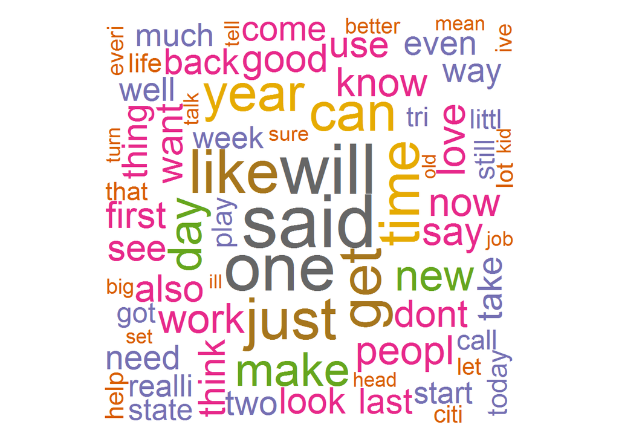

```r
wordcloud(Corpus, scale=c(5,0.75), max.words=150, random.order=FALSE, rot.per=0.25, use.r.layout=FALSE, colors=brewer.pal(8, "Dark2"))
```

As we can see that the three main words are “said”, “will” and “one”.

## Analysis

For the analysis of the dataset, we will proceed to carry out Unigram, Bigram and Trigram which make used of the RWeka Package mainly. ps: I’ve encountered some issue running the codes initially and utlimately realized it was a problem with the Java running on my computer. Do download Java beforehand.

### Unigram

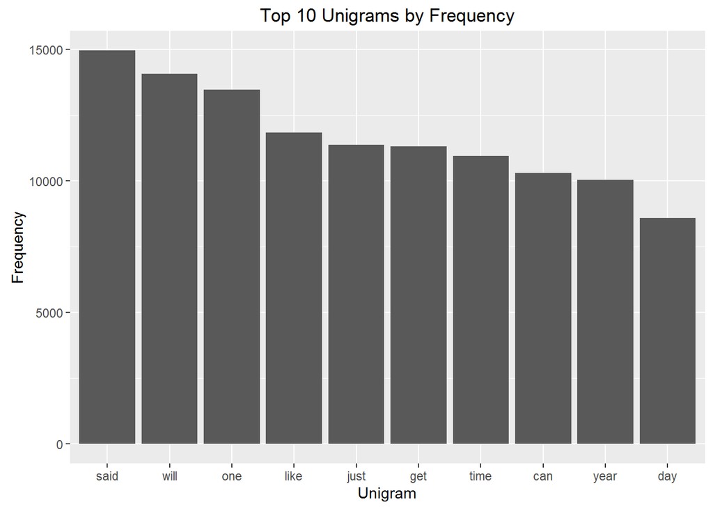

```r
unizer <- function(x) NGramTokenizer(x, Weka_control(min=1, max=1))
unigram <- DocumentTermMatrix(Corpus, control=list(tokenize=unizer))

uniDF <- data.frame(Term=unigram$dimnames$Terms,
                        Freq=unigram$v)
uniDF <- uniDF[with(uniDF, order(-Freq)), ]

ggplot(head(uniDF, 10), aes(reorder(Term, -Freq), Freq)) +
    geom_bar(stat="identity") +
    ggtitle("Top 10 Unigrams by Frequency") +
    xlab("Unigram") + ylab("Frequency")
```

The top Unigrams are “said” followed by “will” and “one”.

### Bigram

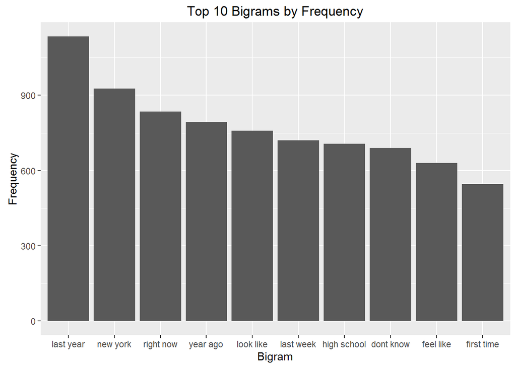

```r
bizer <- function(x) NGramTokenizer(x, Weka_control(min=2, max=2))
bigram <- DocumentTermMatrix(Corpus, control=list(tokenize=bizer))

biDF <- data.frame(Term=bigram$dimnames$Terms,
                        Freq=bigram$v)
biDF <- biDF[with(biDF, order(-Freq)), ]

ggplot(head(biDF, 10), aes(reorder(Term, -Freq), Freq)) +
    geom_bar(stat="identity") +
    ggtitle("Top 10 Bigrams by Frequency") +
    xlab("Bigram") + ylab("Frequency")
```

The top bigrams are “last year”, followed by “new york” and “right now”.

### Trigram

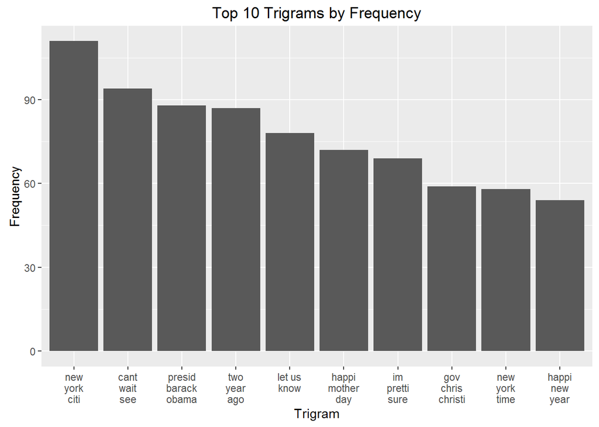

```r
trizer <- function(x) NGramTokenizer(x, Weka_control(min=3, max=3))
trigram <- DocumentTermMatrix(Corpus, control=list(tokenize=trizer))

triDF <- data.frame(Term=trigram$dimnames$Terms,
                       Freq=trigram$v)
triDF <- triDF[with(triDF, order(-Freq)), ]

triDF10 <- head(triDF, 10)

triDF10$newTerm = str_wrap(triDF10$Term, width = 6)

ggplot(head(triDF10, 10), aes(reorder(newTerm, -Freq), Freq)) +
    geom_bar(stat="identity") +
    ggtitle("Top 10 Trigrams by Frequency") +
    xlab("Trigram") + ylab("Frequency")
```

The top trigrams are “new york citi”, followed by “cant wait see” and “presid barack obama”.

# Conclusion

In the milestone report, it allows me to have a better idea about the dataset we will be dealing with. However for the final project - creating a predictive word ShinyApp will be a totally different attempt.Despite limited the dataset to 150,000, the amount of time needed to run the codes is still considerable long. Hence I will expect even more time and resources are needed for doing up the Shinyapp.